# 05-rmd-bib-polish

```r
knitr::opts_chunk$set(echo = FALSE,
                      fig.height = 3,
                      fig.width = 4,
                      dev = "png")
```

# Tasks

- Cite the packages you use when you use them
- hint: http://rmarkdown.rstudio.com/authoring_bibliographies_and_citations.html
- hint: look at the names in packages.bib
- Tidy up the structure, provide some more words around the introduction and results

Principles of tidy data (Wickham 2014)

Principles of tidy data Wickham (2014)

# Introduction

This is a simple analysis of the New York Air Quality Measurements using the R statistical programming language (R Core Team 2017). As stated in the helpfile `?airquality`, this dataset contains

> Daily air quality measurements in New York, May to September 1973.

And the dataset is sourced from:

> … the New York State Department of Conservation (ozone data) and the National Weather Service (meteorological data).

It contains the following variables

- Ozone: Mean ozone in parts per billion from 1300 to 1500 hours at Roosevelt Island.
- Solar.R: Solar radiation in Langleys in the frequency band 4000–7700 Angstroms from 0800 to 1200 hours at Central Park.
- Wind: Average wind speed in miles per hour at 0700 and 1000 hours at LaGuardia Airport.
- Temp: Maximum daily temperature in degrees Fahrenheit at La Guardia Airport.
- Month: Month (1–12)
- Day: Day of month (1–31)

# Method

$$Ozone \sim \beta_0 + \beta_1Solar.R + \beta_2 Wind + \beta_3Temp + \epsilon$$

# Results

We can see that there is an interesting relationship between ozone and solar radiation in figure 1 below, plotted using ggplot2 (Wickham and Chang 2017)

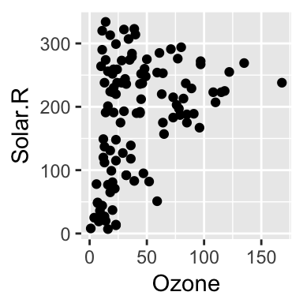

```r
library(ggplot2)
ggplot(airquality,
       aes(x = Ozone,
           y = Solar.R)) +
  geom_point()
```

We can also see that there is an interesting relationship between Ozone and temperature.

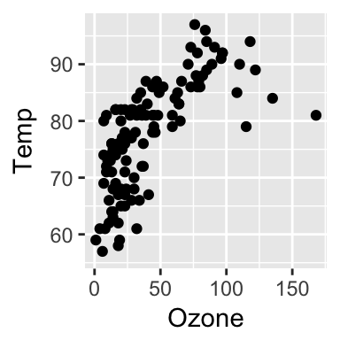

| (Intercept) | -64.3420789 |
| --- | --- |
| Solar.R | 0.0598206 |
| Temp | 1.6520929 |
| Wind | -3.3335913 |

# References

R Core Team. 2017. *R: A Language and Environment for Statistical Computing*. Vienna, Austria: R Foundation for Statistical Computing. https://www.R-project.org/.

Wickham, Hadley. 2014. “Tidy Data.” *Journal of Statistical Software* 59 (10).

Wickham, Hadley, and Winston Chang. 2017. *Ggplot2: Create Elegant Data Visualisations Using the Grammar of Graphics*.